# GAM

# 1 Load Libraries

```r
# installation of packages in case the user has not installed yet
requirements <- c("nnet", "MASS", "e1071", "class", "leaps", "glmnet", "car", "caTools",
              "pROC", "summarytools", "dplyr", "ggplot2", "tidyverse", "lubridate",
              "mapview", "sf", "geojsonio", "leaflet", "broom", "gridExtra",
              "effects")

for (req in requirements){
  if (!require(req, character.only = TRUE)){
      install.packages(req)
  }
}
```

```
## lattice theme set by effectsTheme()
## See ?effectsTheme for details.
```

```r
library(mgcv)
```

# 2 Load Set_Up File

```r
source("00_set_up.R")
# later
train_full <- readRDS("train_all_2020_impute.rds")
test_full  <- readRDS("test_all_2024_impute.rds")
```

```r
na_counts <- colSums(is.na(train_full))
na_counts <- na_counts[na_counts > 0]

for (nm in names(na_counts)) {
  cat(nm, ":", na_counts[nm], "\n")
}
```

```
## co_aqi : 10
## no2_aqi : 66
## so2_aqi : 17
## o3_aqi : 75
```

```r
na_counts_test <- colSums(is.na(test_full))
na_counts_test <- na_counts_test[na_counts_test > 0]

for (nm in names(na_counts_test)) {
  cat(nm, ":", na_counts_test[nm], "\n")
}
```

```
## no2_aqi : 20
## so2_aqi : 13
## o3_aqi : 40
```

```r
summary(train_full)
```

```
##       date                city        co_mean          co_aqi
##  Min.   :2020-01-01   Bronx :366   Min.   :0.100   Min.   : 1.000
##  1st Qu.:2020-04-01   Erie  :366   1st Qu.:0.200   1st Qu.: 2.000
##  Median :2020-07-01   Monroe:366   Median :0.300   Median : 3.000
##  Mean   :2020-07-01   Queens:366   Mean   :0.311   Mean   : 3.653
##  3rd Qu.:2020-10-01                3rd Qu.:0.350   3rd Qu.: 5.000
##  Max.   :2020-12-31                Max.   :1.700   Max.   :20.000
##                                                    NA's   :10
##     no2_mean        no2_aqi         so2_mean          so2_aqi
##  Min.   : 2.40   Min.   : 2.00   Min.   : 0.0000   Min.   : 0.0000
##  1st Qu.:12.40   1st Qu.:12.00   1st Qu.: 0.3000   1st Qu.: 0.0000
##  Median :19.45   Median :19.00   Median : 0.6000   Median : 0.0000
##  Mean   :20.67   Mean   :20.61   Mean   : 0.8562   Mean   : 0.8397
##  3rd Qu.:26.46   3rd Qu.:27.00   3rd Qu.: 1.0500   3rd Qu.: 1.0000
##  Max.   :74.50   Max.   :74.00   Max.   :15.4000   Max.   :43.0000
##                  NA's   :66                        NA's   :17
##    pm2_5_mean       pm2_5_aqi         o3_mean          o3_aqi
##  Min.   : 0.000   Min.   :  4.00   Min.   :0.000   Min.   :  1.00
##  1st Qu.: 4.030   1st Qu.: 28.00   1st Qu.:0.030   1st Qu.: 27.00
##  Median : 5.685   Median : 38.00   Median :0.036   Median : 32.00
##  Mean   : 6.367   Mean   : 38.95   Mean   :0.036   Mean   : 34.63
##  3rd Qu.: 7.855   3rd Qu.: 51.00   3rd Qu.:0.040   3rd Qu.: 40.00
##  Max.   :39.670   Max.   :157.00   Max.   :0.080   Max.   :140.00
##                                                    NA's   :75
##       temp          humidity       windspeed        max_aqi           year
##  Min.   :15.70   Min.   :26.10   Min.   : 4.70   Min.   : 14.0   Min.   :2020
##  1st Qu.:45.00   1st Qu.:56.40   1st Qu.:11.30   1st Qu.: 34.0   1st Qu.:2020
##  Median :58.75   Median :66.40   Median :14.50   Median : 42.0   Median :2020
##  Mean   :58.62   Mean   :65.78   Mean   :15.01   Mean   : 44.1   Mean   :2020
##  3rd Qu.:73.20   3rd Qu.:76.20   3rd Qu.:17.90   3rd Qu.: 52.0   3rd Qu.:2020
##  Max.   :88.20   Max.   :97.40   Max.   :42.00   Max.   :157.0   Max.   :2020
##
##  Main_Pollutant     aqi_level_bin     aqi_level          year_f
##  Length:1464        Min.   :0.0000   Length:1464        2020:1464
##  Class :character   1st Qu.:0.0000   Class :character   2024:   0
##  Mode  :character   Median :0.0000   Mode  :character
##                     Mean   :0.2855
##                     3rd Qu.:1.0000
##                     Max.   :1.0000
##
##      month       month_name
##  01     :124   Jan    :124
##  03     :124   Mar    :124
##  05     :124   May    :124
##  07     :124   Jul    :124
##  08     :124   Aug    :124
##  10     :124   Oct    :124
##  (Other):720   (Other):720
```

```r
head(train_full)
```

```
##         date  city co_mean co_aqi no2_mean no2_aqi so2_mean so2_aqi pm2_5_mean
## 1 2020-01-01 Bronx     0.2      2    16.25      17     0.55       0       4.68
## 2 2020-01-02 Bronx     0.5      6    39.95      38     2.70       4      11.85
## 3 2020-01-03 Bronx     0.6      7    36.95      36     1.40       1      16.23
## 4 2020-01-04 Bronx     0.7      8    27.90      28     1.20       1      11.93
## 5 2020-01-05 Bronx     0.3      3    20.35      19     0.60       0       4.43
## 6 2020-01-06 Bronx     0.3      3    34.95      34     1.70       1       9.48
##   pm2_5_aqi    o3_mean o3_aqi temp humidity windspeed max_aqi year
## 1        42 0.02000000     19 38.2     50.3      18.6      42 2020
## 2        59 0.03600432     NA 41.3     52.2      10.7      59 2020
## 3        68 0.00000000      1 46.8     79.2       6.5      68 2020
## 4        58 0.02000000     22 47.4     89.8      16.4      58 2020
## 5        37 0.03000000     26 38.6     52.1      28.1      37 2020
## 6        54 0.02000000     16 38.6     62.2      17.1      54 2020
##   Main_Pollutant aqi_level_bin aqi_level year_f month month_name
## 1          PM2.5             0   healthy   2020    01        Jan
## 2          PM2.5             1 unhealthy   2020    01        Jan
## 3          PM2.5             1 unhealthy   2020    01        Jan
## 4          PM2.5             1 unhealthy   2020    01        Jan
## 5          PM2.5             0   healthy   2020    01        Jan
## 6          PM2.5             1 unhealthy   2020    01        Jan
```

```r
summary(test_full)
```

```
##       date                city        co_mean           co_aqi
##  Min.   :2024-01-01   Bronx :366   Min.   :0.1000   Min.   : 1.000
##  1st Qu.:2024-04-01   Erie  :366   1st Qu.:0.2000   1st Qu.: 2.000
##  Median :2024-07-01   Monroe:366   Median :0.3000   Median : 3.000
##  Mean   :2024-07-01   Queens:366   Mean   :0.3152   Mean   : 3.687
##  3rd Qu.:2024-10-01                3rd Qu.:0.3500   3rd Qu.: 5.000
##  Max.   :2024-12-31                Max.   :1.5000   Max.   :17.000
##
##     no2_mean        no2_aqi         so2_mean         so2_aqi
##  Min.   : 4.20   Min.   : 4.00   Min.   :0.0000   Min.   : 0.0000
##  1st Qu.:13.18   1st Qu.:12.00   1st Qu.:0.1500   1st Qu.: 0.0000
##  Median :19.77   Median :20.00   Median :0.4000   Median : 0.0000
##  Mean   :21.59   Mean   :21.22   Mean   :0.5686   Mean   : 0.3997
##  3rd Qu.:27.86   3rd Qu.:27.00   3rd Qu.:0.7500   3rd Qu.: 0.0000
##  Max.   :66.65   Max.   :66.00   Max.   :7.7500   Max.   :21.0000
##                  NA's   :20                       NA's   :13
##    pm2_5_mean       pm2_5_aqi         o3_mean           o3_aqi
##  Min.   : 1.000   Min.   :  6.00   Min.   :0.0000   Min.   :  1.00
##  1st Qu.: 4.228   1st Qu.: 28.00   1st Qu.:0.0300   1st Qu.: 27.00
##  Median : 5.900   Median : 39.00   Median :0.0400   Median : 33.00
##  Mean   : 6.712   Mean   : 40.05   Mean   :0.0368   Mean   : 35.56
##  3rd Qu.: 8.450   3rd Qu.: 53.00   3rd Qu.:0.0400   3rd Qu.: 41.00
##  Max.   :27.100   Max.   :109.00   Max.   :0.0800   Max.   :150.00
##                                                     NA's   :40
##       temp          humidity       windspeed        max_aqi
##  Min.   :12.50   Min.   :31.00   Min.   : 4.60   Min.   : 12.00
##  1st Qu.:46.17   1st Qu.:55.17   1st Qu.:11.07   1st Qu.: 34.00
##  Median :61.85   Median :65.90   Median :13.80   Median : 42.00
##  Mean   :59.34   Mean   :65.19   Mean   :14.63   Mean   : 44.96
##  3rd Qu.:73.40   3rd Qu.:75.00   3rd Qu.:17.60   3rd Qu.: 53.00
##  Max.   :89.50   Max.   :95.50   Max.   :39.20   Max.   :150.00
##
##       year      Main_Pollutant     aqi_level_bin     aqi_level
##  Min.   :2024   Length:1464        Min.   :0.0000   Length:1464
##  1st Qu.:2024   Class :character   1st Qu.:0.0000   Class :character
##  Median :2024   Mode  :character   Median :0.0000   Mode  :character
##  Mean   :2024                      Mean   :0.3333
##  3rd Qu.:2024                      3rd Qu.:1.0000
##  Max.   :2024                      Max.   :1.0000
##
##   year_f         month       month_name
##  2020:   0   01     :124   Jan    :124
##  2024:1464   03     :124   Mar    :124
##              05     :124   May    :124
##              07     :124   Jul    :124
##              08     :124   Aug    :124
##              10     :124   Oct    :124
##              (Other):720   (Other):720
```

We have decided to switch to an efficient model which can capture the non-lineariy because the AQI process is not purely linear:

1 **Evidence of non-linearity**: According to scatterplots and residual patterns, a straight line does not adequately represent the connection between **max_aqi** and **pollutants**, particularly **PM2.5_mean** and **o3_mean**.

2 **Better fit without losing interpretability**: In contrast to black-box models, GAM enhances prediction reliability by permitting smooth non-linear effects while maintaining a clear interpretation using partial effect plots.

3. **Environmental realism**: GAM natively captures the thresholds and saturation effects that are frequently present in air pollution phenomena (e.g., once PM2.5 is high, AQI increases fast).

For a “Statistical Inference & Learning” project, GAM is therefore a good compromise because it is more adaptable than LM while remaining inferential and explicable.

A GAM resembles linear regression. However, it enables the data learn a smooth, perhaps curved influence rather than constraining each numerical predictor (like linear regression) to have a straight-line effect.

**s()** function helps a straight line to be smooth and bend, thus allows the model estimate smooth curve. In GAM, we can get a function **f(x)** that can bend as its own way.

Many real relationships in air quality are non-linear, for example:

- **pm_2_5_mean** may have a slow effect at low levels but a strong effect after a particular value.
- **o3_mean** can behave differently in different ranges (flat -> then sharp rise)
- **Temperature** effects can be weak in mid-range but stronger at extremes

In LM, if *pm2_5_mean **increases by 1 unit,** max_aqi** always increases by the same amount. In GAM, *pm2_5_mean** increases by 1 unit, the effect on *max_aqi **depends on where you are on the** pm2_5_mean** scale.

So GAM keeps the model additive and interpretable, but removes the “must be linear” restriction.

# 3 Simple GAM

```r
fit_gam <- gam(max_aqi ~ city +
                  s(pm2_5_mean, k=6) +
                  s(o3_mean,     k=6) +
                  s(so2_mean,    k=6) +
                  s(temp,        k=6) +
                  no2_mean + co_mean + humidity + windspeed,
                data = train_full)

summary(fit_gam)
```

```
##
## Family: gaussian
## Link function: identity
##
## Formula:
## max_aqi ~ city + s(pm2_5_mean, k = 6) + s(o3_mean, k = 6) + s(so2_mean,
##     k = 6) + s(temp, k = 6) + no2_mean + co_mean + humidity +
##     windspeed
##
## Parametric coefficients:
##              Estimate Std. Error t value Pr(>|t|)
## (Intercept) 47.678129   1.021415  46.679  < 2e-16 ***
## cityErie    -3.629107   0.409655  -8.859  < 2e-16 ***
## cityMonroe  -2.224849   0.446473  -4.983 7.01e-07 ***
## cityQueens  -0.899199   0.374955  -2.398   0.0166 *
## no2_mean     0.016276   0.019578   0.831   0.4059
## co_mean     -2.455822   1.288226  -1.906   0.0568 .
## humidity    -0.020072   0.011057  -1.815   0.0697 .
## windspeed   -0.009672   0.028416  -0.340   0.7336
## ---
## Signif. codes:  0 '***' 0.001 '**' 0.01 '*' 0.05 '.' 0.1 ' ' 1
##
## Approximate significance of smooth terms:
##                 edf Ref.df      F p-value
## s(pm2_5_mean) 4.918  4.996 714.70  <2e-16 ***
## s(o3_mean)    4.983  5.000 374.42  <2e-16 ***
## s(so2_mean)   4.409  4.820   2.56  0.0477 *
## s(temp)       3.703  4.346  10.41  <2e-16 ***
## ---
## Signif. codes:  0 '***' 0.001 '**' 0.01 '*' 0.05 '.' 0.1 ' ' 1
##
## R-sq.(adj) =  0.882   Deviance explained = 88.4%
## GCV = 23.818  Scale est. = 23.394    n = 1464
```

Here, in the **GAM** function, the dimension of the basis function is kept as 6, which means that represent the unknown smooth function of predictors using a basis with 6 building blocks (basis functions). So instead of fitting a single straight line, the model fits a flexible curve, built as a weighted sum of those 6 basis functions. **k** controls the maximum complexity the curve is allowed to have, before penalization. - **Small k** -> curve can only be simple (few bends). - **Large k** -> curve can be more wiggly (more bends allowed), if the data really supports it.

**edf** - **edf ≈ 1** -> the smooth is basically linear (no real curvature). - **larger edf** -> more curvature

Key diagnostic rule:

If edf is close to the maximum possible for that k, you likely set k too small (the model is “hitting the ceiling”).

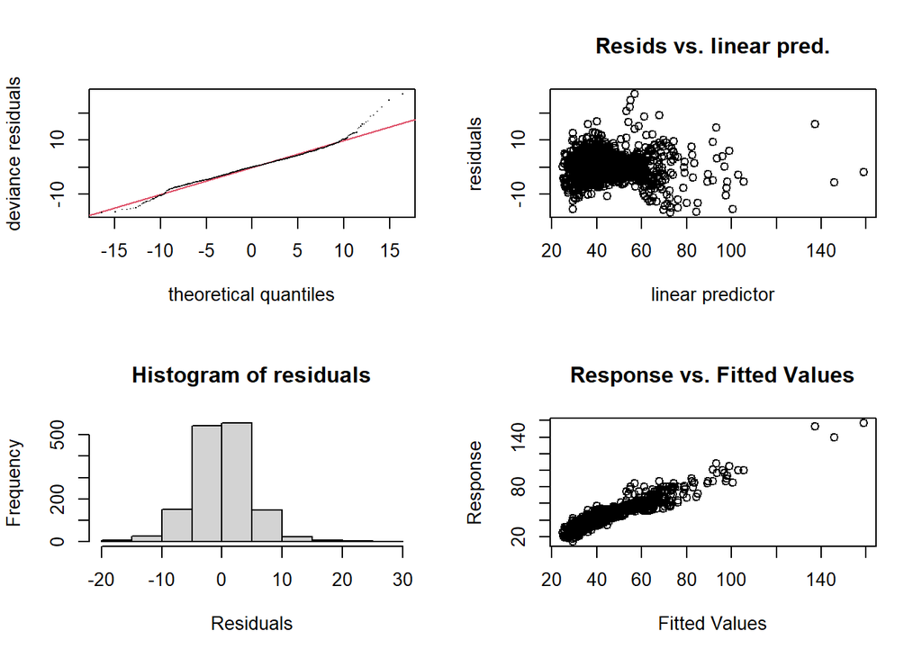

```
##
## Method: GCV   Optimizer: magic
## Smoothing parameter selection converged after 14 iterations.
## The RMS GCV score gradient at convergence was 4.767359e-06 .
## The Hessian was positive definite.
## Model rank =  28 / 28
##
## Basis dimension (k) checking results. Low p-value (k-index<1) may
## indicate that k is too low, especially if edf is close to k'.
##
##                 k'  edf k-index p-value
## s(pm2_5_mean) 5.00 4.92    0.98    0.20
## s(o3_mean)    5.00 4.98    0.84  <2e-16 ***
## s(so2_mean)   5.00 4.41    0.95    0.01 **
## s(temp)       5.00 3.70    1.00    0.44
## ---
## Signif. codes:  0 '***' 0.001 '**' 0.01 '*' 0.05 '.' 0.1 ' ' 1
```

```r
gam.check(fit_gam)
```

k′: the effective maximum complexity allowed for that smooth (after constraints). I set k=6, and for 1D smooths mgcv reports k′ ≈ 5 (normal).

edf: the effective degrees of freedom actually used (how curvy the fitted smooth became).

k-index: a diagnostic; should be ~ 1 if k is adequate. < 1 suggests k might be too small (model wants more flexibility).

p-value: tests whether the pattern suggests k is too small. Small p-value (e.g., <0.05) ⇒ evidence k is too low.

For **s(pm2_5_mean)**, probably increase k a little bit, edf = 4.91 is basically near to the maximum (k′=5.00). Safer to raise k moderately.

For **s(temp)**, edf is very far from k, so k = 5 is okay.

# 4 SImple GAM (Select K)

```r
fit_gam_k <- gam(max_aqi ~ city + s(pm2_5_mean, k=8) +
                  s(o3_mean,     k=10) +
                  s(so2_mean,    k=8) +
                  s(temp,        k=5) +
                  no2_mean + co_mean + humidity + windspeed,
                data = train_full)

summary(fit_gam_k)
```

```
##
## Family: gaussian
## Link function: identity
##
## Formula:
## max_aqi ~ city + s(pm2_5_mean, k = 8) + s(o3_mean, k = 10) +
##     s(so2_mean, k = 8) + s(temp, k = 5) + no2_mean + co_mean +
##     humidity + windspeed
##
## Parametric coefficients:
##             Estimate Std. Error t value Pr(>|t|)
## (Intercept) 47.26357    1.00025  47.252  < 2e-16 ***
## cityErie    -3.32974    0.40332  -8.256 3.38e-16 ***
## cityMonroe  -2.00030    0.43864  -4.560 5.54e-06 ***
## cityQueens  -0.82424    0.36898  -2.234   0.0256 *
## no2_mean     0.02364    0.01916   1.234   0.2174
## co_mean     -2.02086    1.26142  -1.602   0.1094
## humidity    -0.02029    0.01080  -1.880   0.0604 .
## windspeed   -0.01022    0.02781  -0.368   0.7133
## ---
## Signif. codes:  0 '***' 0.001 '**' 0.01 '*' 0.05 '.' 0.1 ' ' 1
##
## Approximate significance of smooth terms:
##                 edf Ref.df       F p-value
## s(pm2_5_mean) 6.817  6.987 540.406  <2e-16 ***
## s(o3_mean)    8.669  8.964 223.210  <2e-16 ***
## s(so2_mean)   4.179  5.024   1.616   0.151
## s(temp)       3.525  3.875  10.336  <2e-16 ***
## ---
## Signif. codes:  0 '***' 0.001 '**' 0.01 '*' 0.05 '.' 0.1 ' ' 1
##
## R-sq.(adj) =  0.888   Deviance explained =   89%
## GCV = 22.779  Scale est. = 22.294    n = 1464
```

Now we have fitted a GAM (Generalized Additive Model) with a Gaussian response.

- **Intercept** = 47.26 (highly significant)
- **City coefficients** all negative and significant.
- **no2_mean**, **co_mean** and **windspeed** are not statistically significant.
- **humidity**: mild evidence that higher humidity is associated with slightly lower max_aqi

In GAM output, each smooth has:

- **edf (effective degrees of freedom):** how flexible the fitted curve actually is
  - **edf ≈ 1** → almost linear
  - **higher edf** → more nonlinear “wiggly” curve
- **F statistic & p-value:** large and small respectively if that smooth term contributes significantly.
1. **s(pm2_5_mean)**: edf is 6.817 and p_value is very small means that PM2.5 has a **strong nonlinear 2. relationship** with *max_aqi**.
2. **s(o3_mean)**: edf is 8.669 and p_value is very small means that o3 also has a **strong nonlinear relationship** with max_aqi.
3. **s(so2_mean)**: not significant. **so2** is either weak in these cities/years or its information is redundant once other pollutants are included
4. **s(temp)**: Its also has a significant effect with edf 3.525.

The two main very substantial and significantly nonlinear components are **pm2_5_mean** and **o3_mean**. Temperature is important as well. However, after adjusting for other factors, *so2_mean** does not exhibit an additional significant impact.

**Model Performance Matrics**

- **Adjusted $R^2$** is 0.888 which means that the model can explain about $89\%$ variability in max_aqi. For environmental data with noise this is quite strong.
- **Deviance explained** is $89\%$, another way of variance explanation. So, here, we can see that the model fits data well.

The model explains around $89\%$ of the variance, indicating a strong predictive structure that is primarily caused by PM2.5 and O₃ nonlinearities. The remaining error is probably caused by daily unobserved factors.

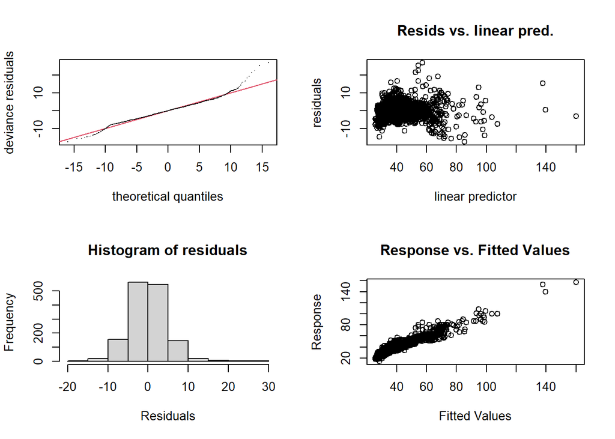

```
##
## Method: GCV   Optimizer: magic
## Smoothing parameter selection converged after 15 iterations.
## The RMS GCV score gradient at convergence was 2.903797e-05 .
## The Hessian was positive definite.
## Model rank =  35 / 35
##
## Basis dimension (k) checking results. Low p-value (k-index<1) may
## indicate that k is too low, especially if edf is close to k'.
##
##                 k'  edf k-index p-value
## s(pm2_5_mean) 7.00 6.82    1.01   0.595
## s(o3_mean)    9.00 8.67    0.87  <2e-16 ***
## s(so2_mean)   7.00 4.18    0.96   0.065 .
## s(temp)       4.00 3.53    0.98   0.210
## ---
## Signif. codes:  0 '***' 0.001 '**' 0.01 '*' 0.05 '.' 0.1 ' ' 1
```

```r
gam.check(fit_gam_k)
```

We increased the k for **PM_2_5_mean** and **o3_mean** to 8 and 10 respectively, meaning the model actually needed that flexibility.

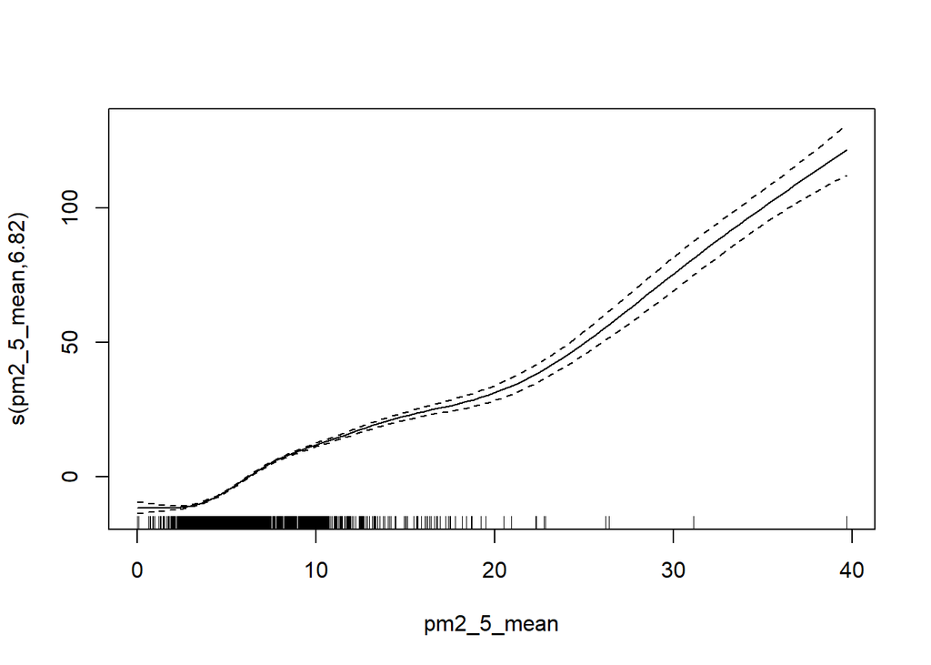

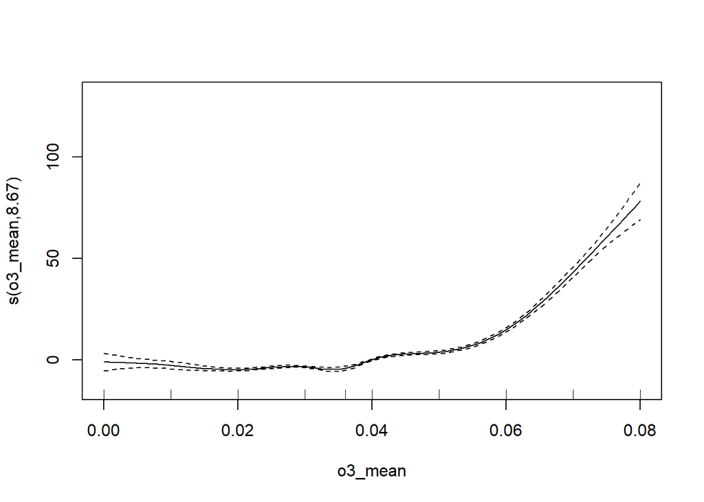

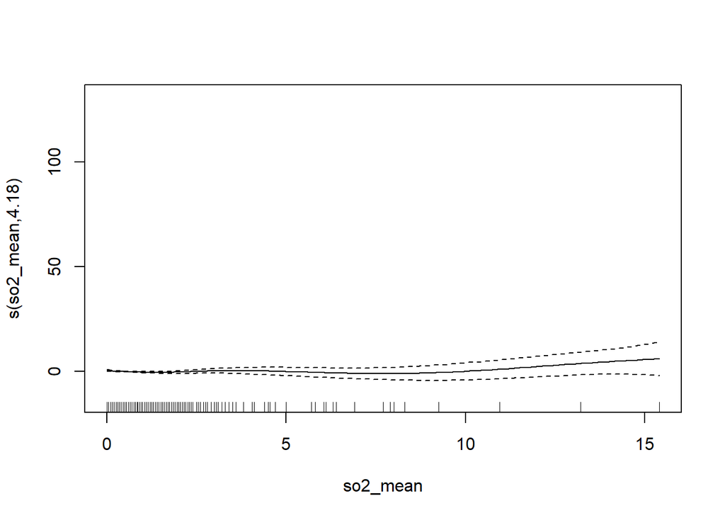

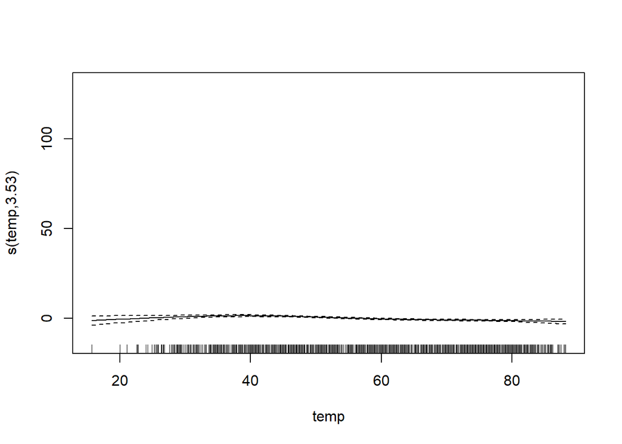

```r
#par(mfrow=c(2,2))
#plot(fit_gam_k)

plot(fit_gam_k, shade = TRUE, shade.col = "lightblue")
```

**s(o3_mean)** nearly flat at low **o₃_mean**, then sharp upward increase after some threshold-ish region (around ~0.05–0.06 in the scale). This “flat then jump” shape says: **o₃_mean** becomes very influential only when it gets high. Bands widen at the far right -> fewer data points at high **o₃_mean**, so less certainty. Therefore, **o₃_mean** has a nonlinear “risk escalation” effect at higher values.

**s(so2_mean)** the line is almost flat, small changes only. Consistent with our summary where **s(so2_mean)** smooth was not significant. After controlling for **s(pm2_5_mean)** and **s(o3_mean)**, **s(so2_mean)** adds little extra predictive power in this model (in the data/time).

**s(temp)**, the curve is very close to flat. Even if p-value was significant in summary, the effect size is small in AQI units (flat curve = small contribution). Temperature’s additional contribution is minor compared to **s(pm2_5_mean)** and **s(o3_mean)**.

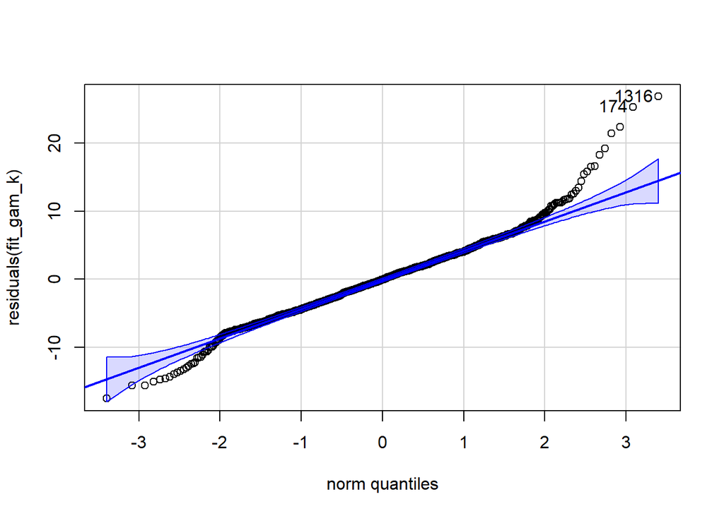

```
## [1] 1316  174
```

```r
qqPlot(residuals(fit_gam_k))
```

Most points (the big chunk around the center) lie close to the diagonal → most residuals behave roughly normal.

Most points (the big chunk around the center) lie close to the diagonal → most residuals behave roughly normal. On the right side, the severe big residual means the model cannot predict well when the **max_aqi** is higher. In the left tail, the residual is very low indicating that when *max_aqi** is very low, model predicts them very high. This pattern usually means heavier tails than Normal (outliers / extreme days).

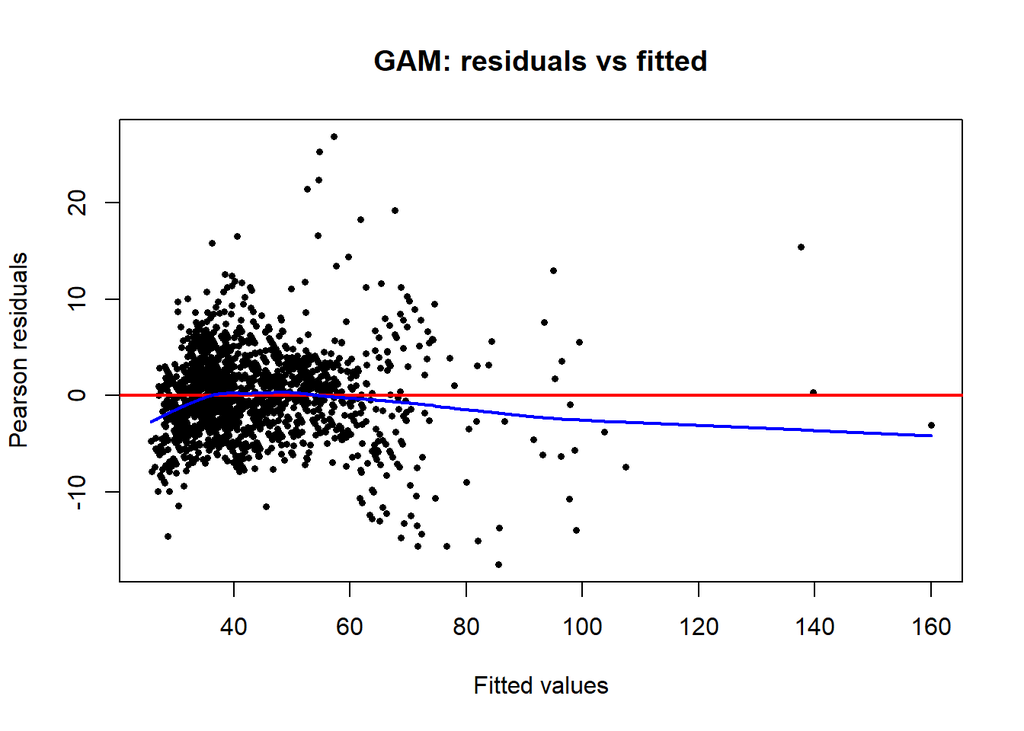

```r
rstd_gam <- residuals(fit_gam_k, type = "pearson")
yhat_gam <- fitted(fit_gam_k)
n_gam    <- length(rstd_gam)

# 1) residuals vs fitted values
ok <- is.finite(yhat_gam) & is.finite(rstd_gam)
plot(yhat_gam[ok], rstd_gam[ok], pch=16, cex=0.6,
     xlab="Fitted values", ylab="Pearson residuals",
     main="GAM: residuals vs fitted")
abline(h=0, col="red", lwd=2)
lines(lowess(yhat_gam[ok], rstd_gam[ok]), col="blue", lwd=2)
```

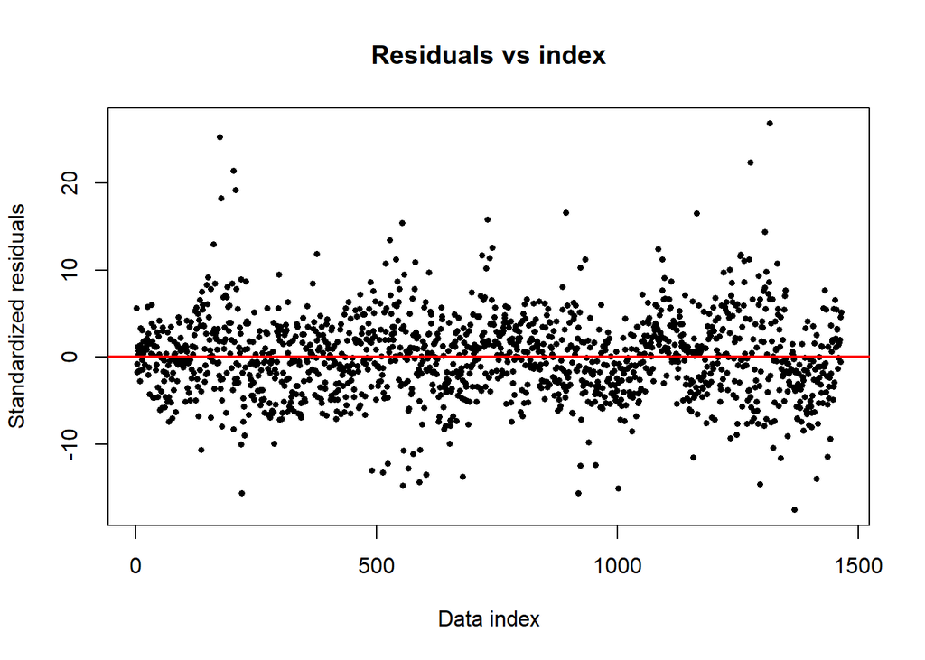

```r
# 2) residuals vs data index
plot(1:n_gam, rstd_gam, pch=16, cex=0.6,
     xlab="Data index", ylab="Standardized residuals",
     main="Residuals vs index")
abline(h=0, col="red", lwd=2)
```

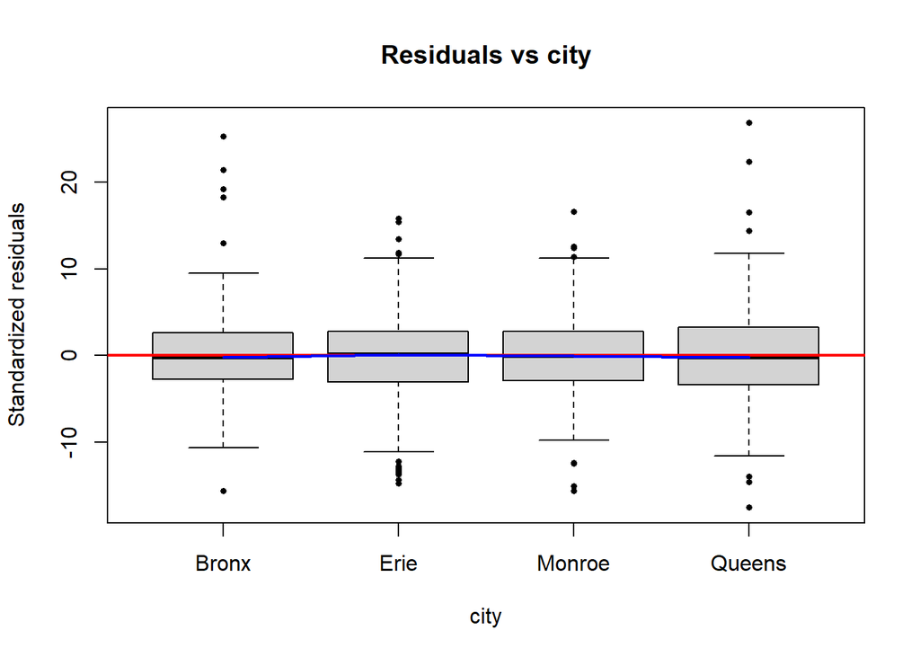

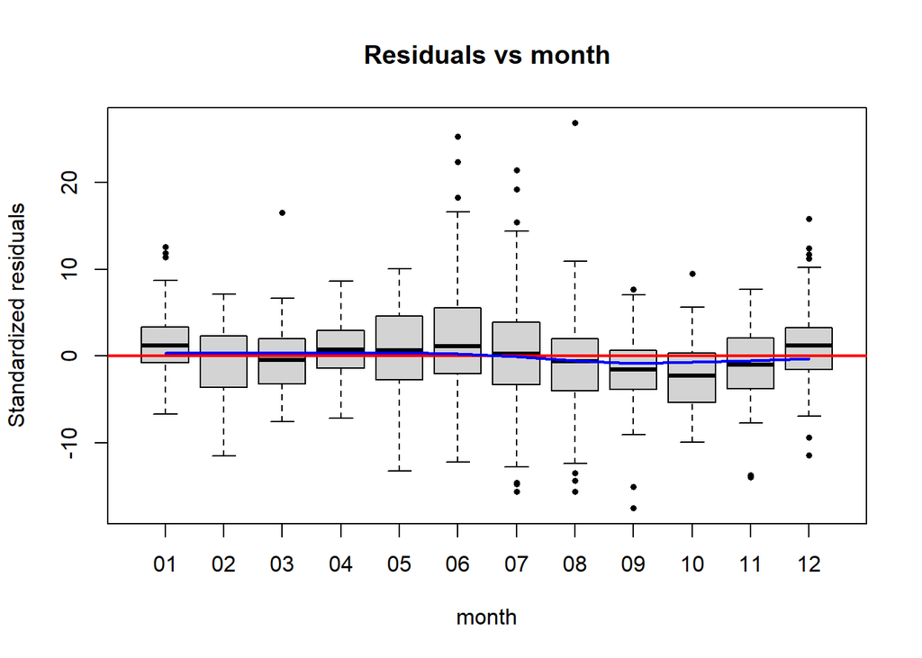

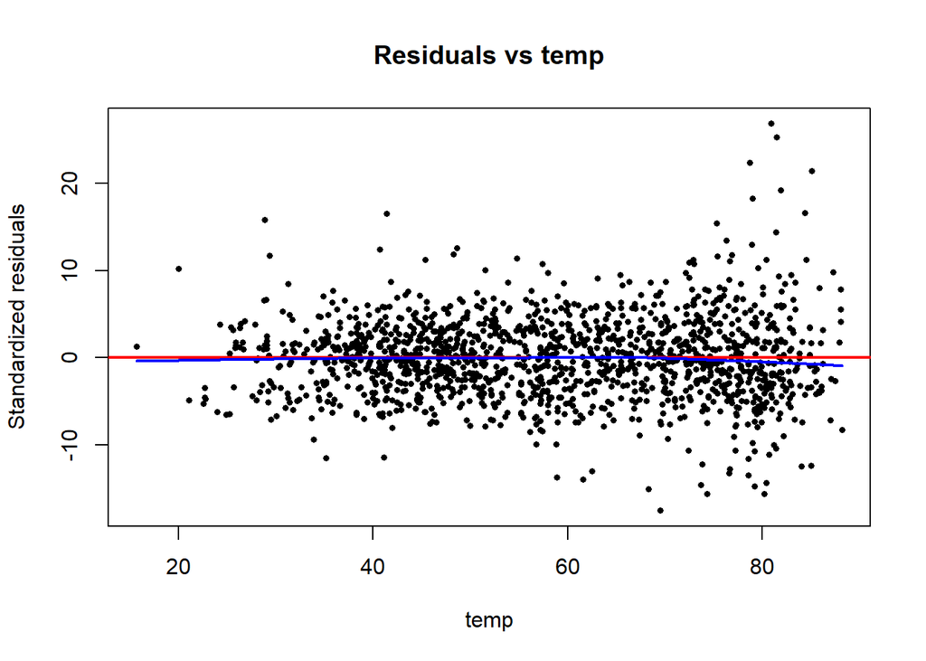

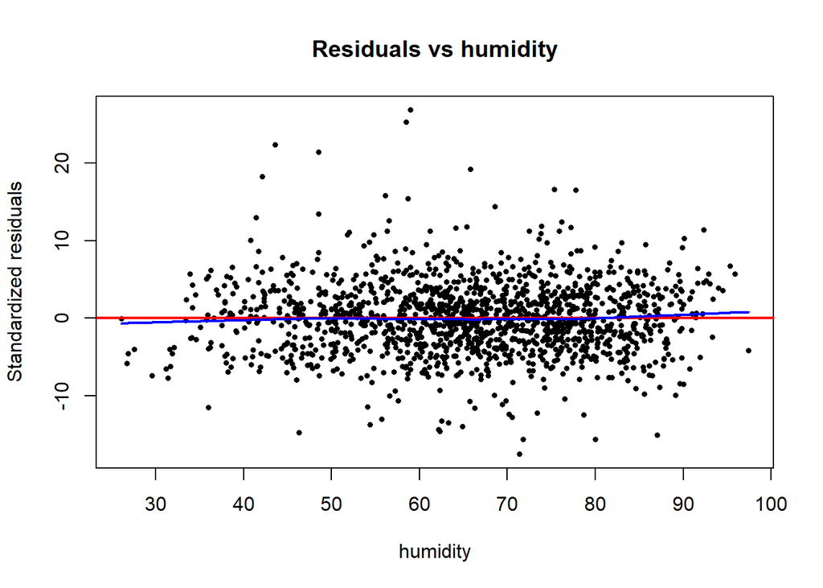

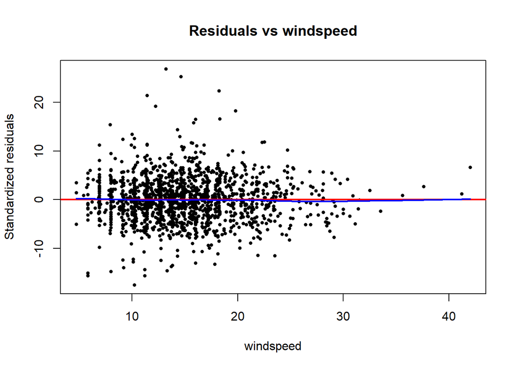

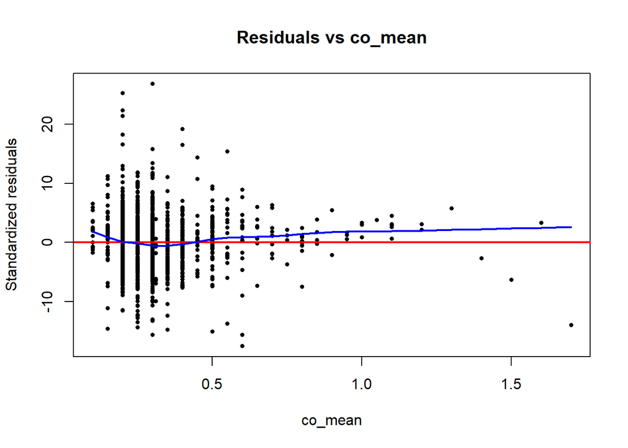

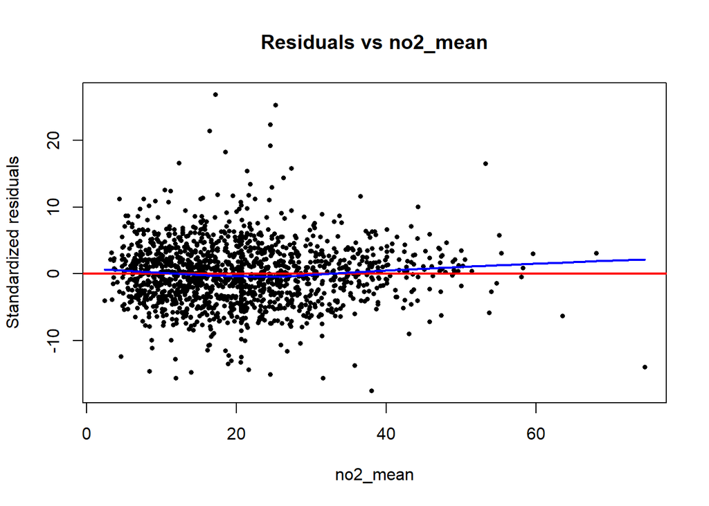

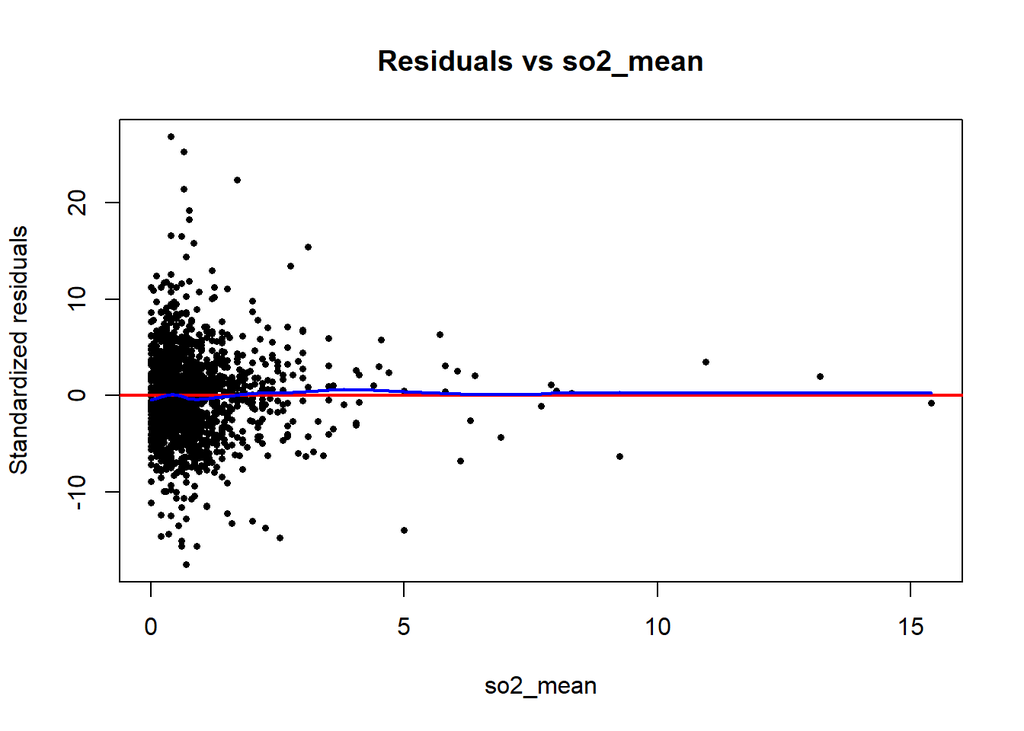

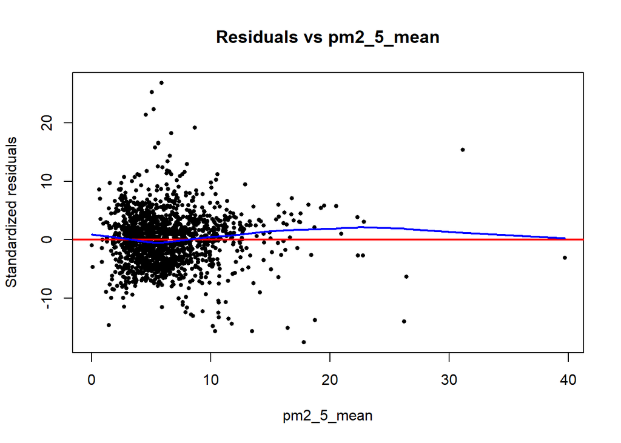

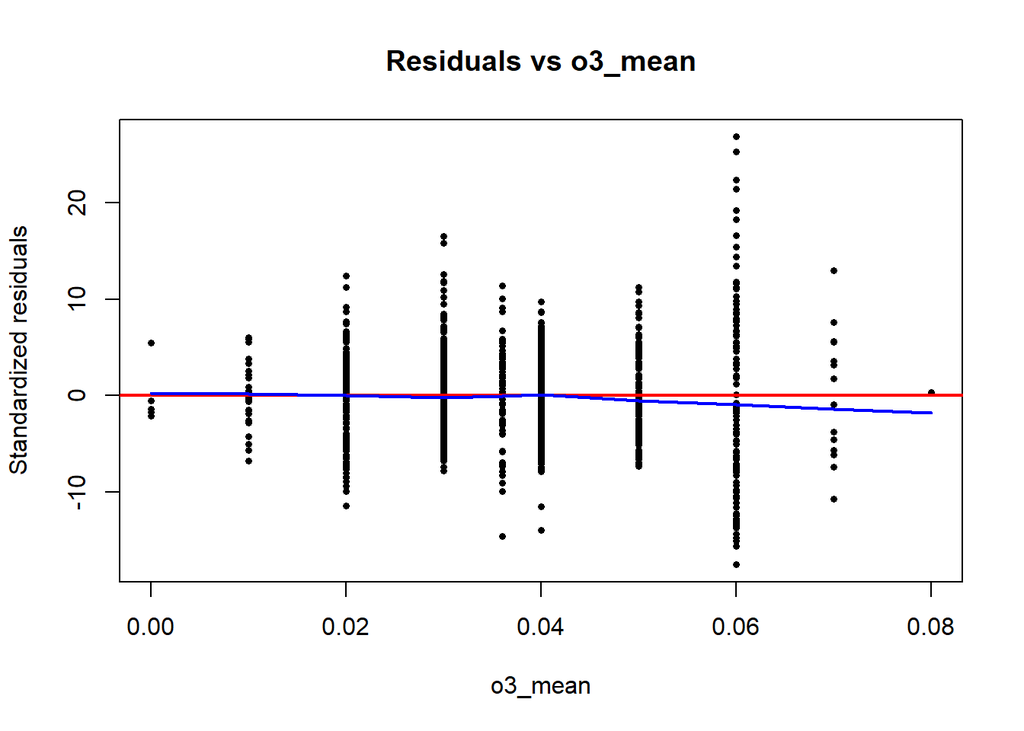

```r
# 3) residuals vs predictors (one by one)
train_full$city <- factor(train_full$city)

Xcols <- c("city", "month", "temp","humidity","windspeed",
           "co_mean","no2_mean","so2_mean","pm2_5_mean","o3_mean")

for (x in Xcols) {
  xx <- train_full[[x]]
  ok <- is.finite(xx) & is.finite(rstd_gam)

  plot(xx[ok], rstd_gam[ok], pch=16, cex=0.6,
       xlab=x, ylab="Standardized residuals",
       main=paste("Residuals vs", x))
  abline(h=0, col="red", lwd=2)
  lines(lowess(xx[ok], rstd_gam[ok]), col="blue", lwd=2)
}
```

- **Residuals vs fitted**:The majority of residuals are centred around 0 (good). However, the model tends to slightly overestimate when the projected max AQI spikes (a bit of residual bias in the upper range), as the blue smooth line dips downwards slightly for bigger fitted values.
- **Residuals vs index**: Although there are a few large outliers and some extreme days are poorly captured (common for AQI spikes), points appear pretty “random” around 0 (good: no strong time-order structure).
- **Residuals vs city (boxplot)**: All cities’ medians are near zero, which is fine, but some have greater spreads or outliers. Overall, the city impact is managed, but severe events differ by city.
- **Residuals vs month**: A month smooth (cyclic) can be helpful because most months are centred around 0, but others have wider vertical spreads or outliers, which implies seasonality may still be inadequately recorded.
- **Residuals vs humidity / no2_mean**: The model has already captured their contribution (or they are poor predictors in this model) because the smooth line is nearly flat around 0 -> no substantial leftover structure.
- **Residuals vs co_mean / pm2_5_mean**: A small systematic deviation in the smooth line suggests that either the selected smooth (for PM2.5) or a simply linear impact (for CO) may not be sufficient, or that some interaction (for example, with windspeed/pm_2_5_mean or temp/month) could account for the residual pattern.
- **Residuals vs so2_mean**: The majority of the data are concentrated at low SO₂ (strong skew), with a few distant points. Because **so2_mean** has numerous small values and a few infrequent spikes, it is difficult to identify the residual pattern in this case.
- **Residuals vs temp**: The residual doesnot show any drift.

The model is generally acceptable according to these plots, but upper-tail AQI days plus some seasonality and interaction structure still create patterns in the residuals. For this reason, the following models should try cyclic month smooth + interactions.

```r
pred_gam <- predict(fit_gam_k, newdata = test_full)

rmse_fit_gam_k <- rmse(test_full$max_aqi, pred_gam)
rmse_fit_gam_k
```

```
## [1] 5.178919
```

```r
resid_aqi_gam <- test_full$max_aqi - pred_gam
rse_fit_gam <- sqrt(sum(resid_aqi_gam^2, na.rm = TRUE) / (sum(!is.na(resid_aqi_gam)) - 1))
rse_fit_gam
```

```
## [1] 5.180689
```

# 5 GAM BOX_COX/powerTransform

```r
powerTransform(fit_gam_k)
```

```
## Estimated transformation parameter
##        Y1
## 0.4494224
```

```r
lambda <- 0.4494224

# Box-Cox transform of Y
train_full$y_bc <- (train_full$max_aqi^lambda - 1) / lambda

fit_gam_k_bc <- update(fit_gam_k, y_bc  ~ .)

summary(fit_gam_k_bc)
```

```
##
## Family: gaussian
## Link function: identity
##
## Formula:
## y_bc ~ city + s(pm2_5_mean, k = 8) + s(o3_mean, k = 10) + s(so2_mean,
##     k = 8) + s(temp, k = 5) + no2_mean + co_mean + humidity +
##     windspeed
##
## Parametric coefficients:
##              Estimate Std. Error t value Pr(>|t|)
## (Intercept) 10.283114   0.128698  79.901  < 2e-16 ***
## cityErie    -0.427197   0.051905  -8.230 4.15e-16 ***
## cityMonroe  -0.251281   0.056524  -4.446 9.44e-06 ***
## cityQueens  -0.098557   0.047479  -2.076   0.0381 *
## no2_mean     0.002404   0.002463   0.976   0.3292
## co_mean     -0.179000   0.162232  -1.103   0.2701
## humidity    -0.003176   0.001389  -2.287   0.0224 *
## windspeed   -0.002423   0.003576  -0.678   0.4981
## ---
## Signif. codes:  0 '***' 0.001 '**' 0.01 '*' 0.05 '.' 0.1 ' ' 1
##
## Approximate significance of smooth terms:
##                 edf Ref.df       F p-value
## s(pm2_5_mean) 6.797  6.984 457.547  <2e-16 ***
## s(o3_mean)    8.790  8.985 155.629  <2e-16 ***
## s(so2_mean)   4.394  5.249   1.995  0.0705 .
## s(temp)       3.669  3.937  14.229  <2e-16 ***
## ---
## Signif. codes:  0 '***' 0.001 '**' 0.01 '*' 0.05 '.' 0.1 ' ' 1
##
## R-sq.(adj) =  0.864   Deviance explained = 86.7%
## GCV = 0.37673  Scale est. = 0.36859   n = 1464
```

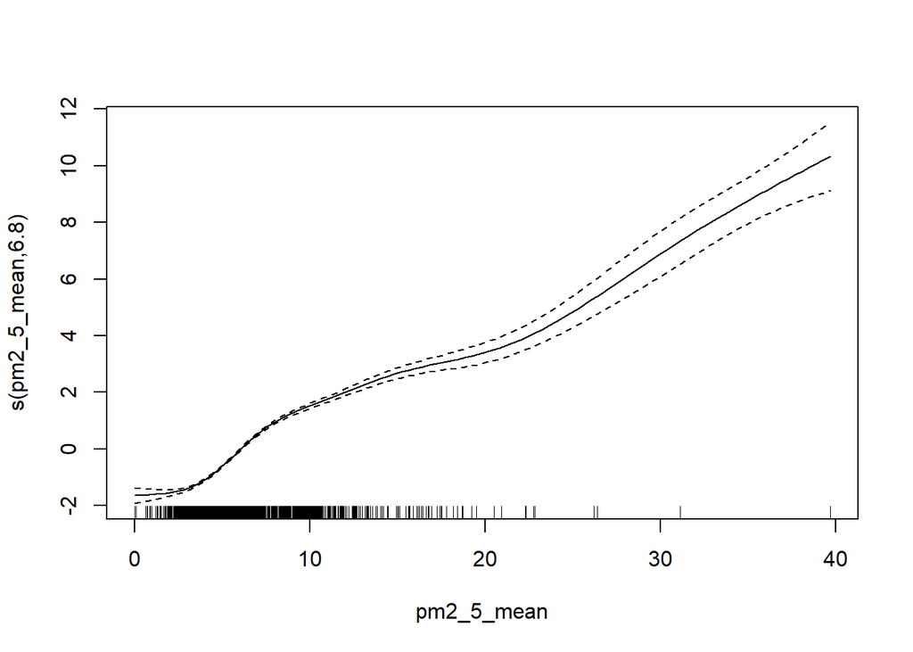

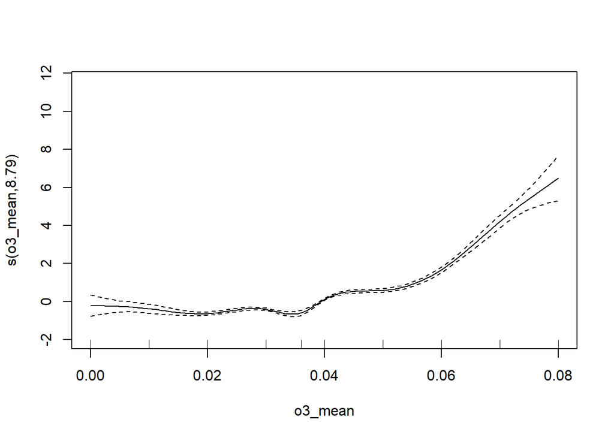

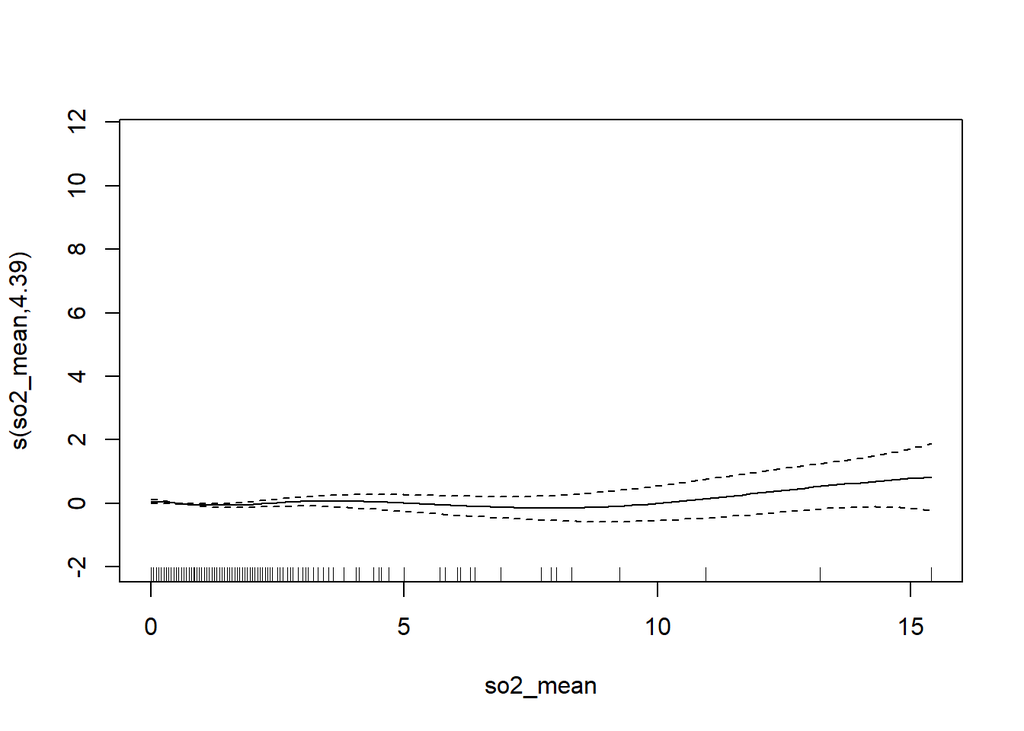

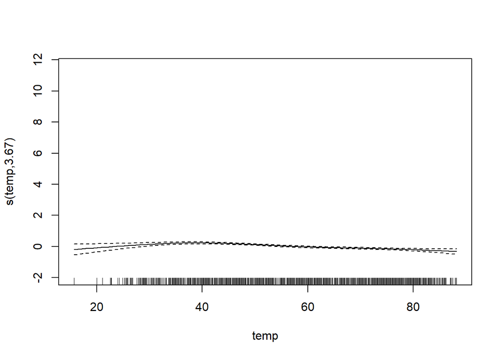

```r
plot(fit_gam_k_bc, shade = TRUE, shade.col = "lightblue")
```

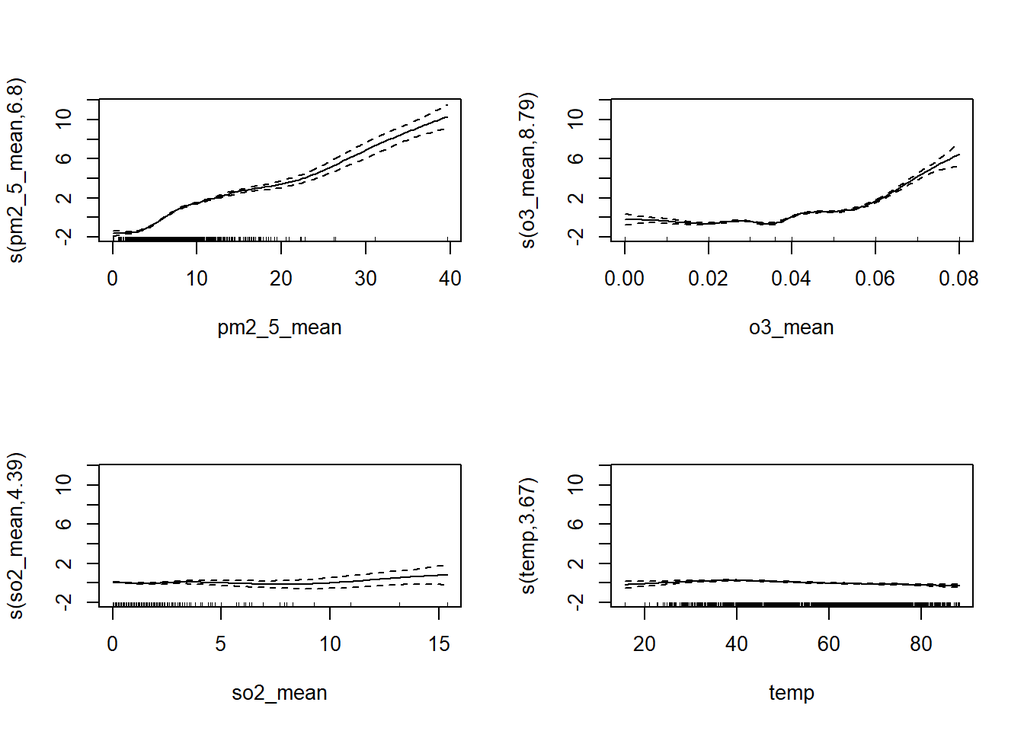

```r
par(mfrow=c(2,2))
plot(fit_gam_k_bc)
```

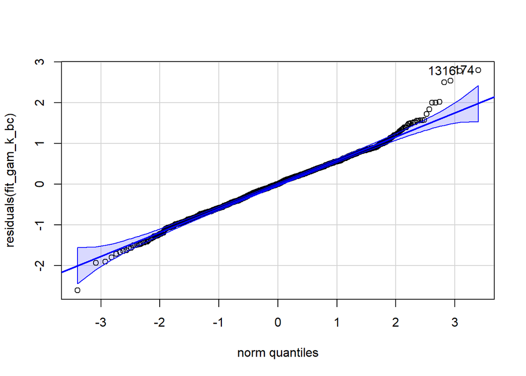

```
## [1]  174 1316
```

```r
qqPlot(residuals(fit_gam_k_bc))
```

The Q-Q plot is significantly improved after applying the transformation on the target variable. there is only one point is outside the interval in the left tail and the right tail has been also improved.

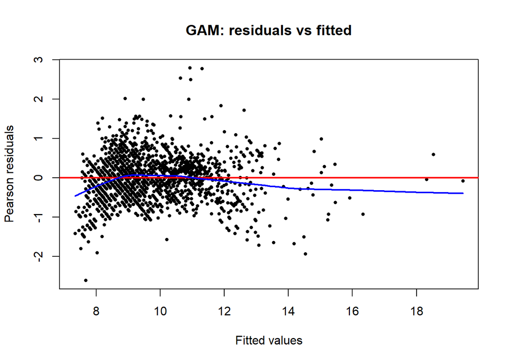

```r
rstd_gam_bc <- residuals(fit_gam_k_bc, type = "pearson")
yhat_gam_bc <- fitted(fit_gam_k_bc)
n_gam_bc    <- length(rstd_gam)

# 2) residuals vs fitted values
ok <- is.finite(yhat_gam_bc) & is.finite(rstd_gam_bc)
plot(yhat_gam_bc[ok], rstd_gam_bc[ok], pch=16, cex=0.6,
     xlab="Fitted values", ylab="Pearson residuals",
     main="GAM: residuals vs fitted")
abline(h=0, col="red", lwd=2)
lines(lowess(yhat_gam_bc[ok], rstd_gam_bc[ok]), col="blue", lwd=2)
```

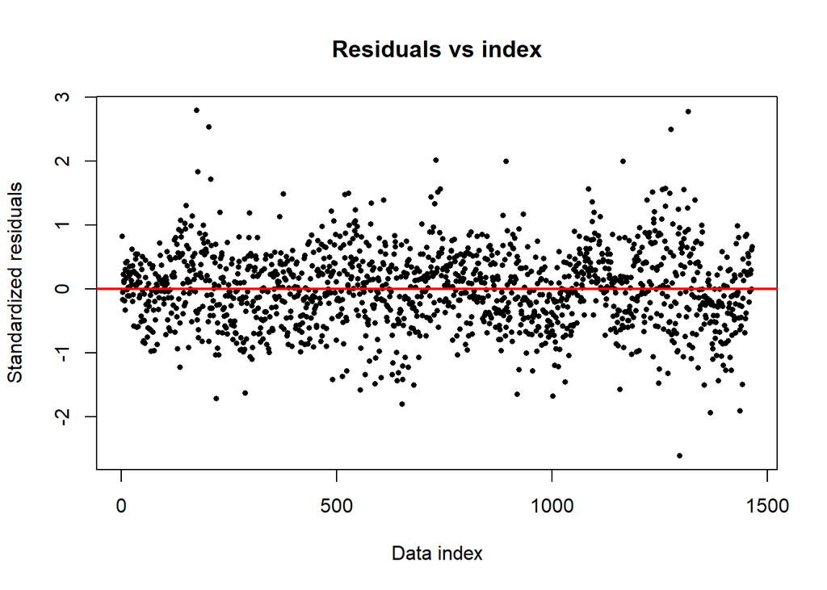

```r
# 1) residuals vs data index
plot(1:n_gam_bc, rstd_gam_bc, pch=16, cex=0.6,
     xlab="Data index", ylab="Standardized residuals",
     main="Residuals vs index")
abline(h=0, col="red", lwd=2)
```